# Unicef Argentina : Rapport d’étude statistique

Kenza Hamaz

### I. Introduction

L’UNICEF Argentine nous donne pour mission de déterminer quelles sont exactement les régions qui correspondraient le plus aux deux profils recherchés par les programmes suivants:

• Le programme “Women empowerment” : destiné à sortir de la pauvreté une population particulièrement vulnérable, le programme vise à renforcer les capacités d’autonomisation des mères seules avec enfants dans les deux provinces **les plus vulnérables** (4 millions de dollars en 2021).  
• Le programme “No-Poor” : destiné à soutenir le revenu des familles vulnérables afin qu’elles ne tombent pas en-dessous du seuil de pauvreté dans les deux provinces **les plus riches et les mieux dotées en matière de développement** (15 millions de dollars en 2021). Le programme retient comme vulnérables, les familles dont le revenu se situe au-dessus du seuil de pauvreté mais en-dessous de la limite de 5 fois ce seuil.

Pour répondre à leurs attentes, nous allons finalement tenter de cibler les régions les plus vulnérables d’une part, et celles qui sont les plus riches d’autres part, puisque ce sont ces régions qui doivent être financées dans le cadre des programmes. Le document suivant correspond donc à un rapport de data mining (statistiques exploratoires) permettant de répondre aux attentes du commenditaire, et propose un découpage entre régions pauvres et riches. Mais pour cela, la notion de pauvreté doit dans un premier temps être bien claire.

### II. Pauvreté, quelques definitions

La pauvreté est un concept multidimensionnel, et de ce fait relativement difficile à définir.  
Il n’y a ainsi pas de consensus quant à sa définition et l’on retrouve dans la littérature plusieurs types de pauvreté.

Le Programme des Nations Unies pour le développement (PNUD), dans son rapport Vaincre la pauvreté humaine, distingue à lui seul trois types ou degrés de pauvreté :

L’ « extrême pauvreté » évoque des difficultés à satisfaire ses besoins alimentaires, tandis que la « pauvreté générale » concerne des besoins essentiels mais non alimentaires (logement, habillement,…) et auxquels le revenu ne permet pas de subvenir.  
Enfin la « pauvreté humaine » correspond à « l’absence des capacités humaines de base : analphabétisme, malnutrition, longévité réduite, mauvaise santé maternelle, maladie pouvant être évitée » [PNUD 2000, dans Benicourt 2017].  
L’indicateur utilisé pour appréhender la pauvreté est l’indicateur de pauvreté humaine qui « se concentre sur trois aspects essentiels de la vie humaine déjà envisagés dans le cadre de l’IDH [indicateur de développement humain] – longévité, instruction et conditions de vie décentes – mais envisage ces aspects sous l’angle des manques.»

La Banque mondiale (BM) distingue quant à elle « pauvreté absolue » qui est déterminée par un seuil minimum de revenu à posséder pour pouvoir assurer sa propre survie ainsi que la « pauvreté relative » qui s’apparente davantage à une comparaison de son revenu avec celui de l’environnement [BM 2000, dans Benicourt 2017].  
Dans les deux cas, la pauvreté est évaluée en fonction du revenu, et on parle alors de pauvreté monétaire. Même si son approche est centrée sur le revenu, la BM ne se limite pas à cette unique dimension et passe en revue dans son rapport d’autres dimensions et indicateurs afin de mieux comprendre le concept de pauvreté.

### III. Description des données

Nous disposons de la base de données “Argentina Socio-Economic Data by Province 2020” qui présente des données sur des variables socio-économiques concernant les provinces d’Argentine en 2020. Dans cette base de données on a initialement 22 observations concernant les 11 variables suivantes :

- province : nom de la province
- gdp : PIB (en dollar)
- illiteracy : taux de la population n’ayant pas eu d’éducation formelle
- poverty : taux de pauvreté (pourcentage de la population en dessous du seuil de pauvreté)
- deficient_infra : manque d’infrastructure (taux par infrastructure)
- school_dropout : taux d’abandon scolaire
- no_healthcare : pas de soins de santé (taux par population active)
- birth_mortal : mortalité à la naissance (taux pour 1000 naissances vivantes)
- pop : population (total d’habitants)
- movie_theatres_per_cap : Salles de cinéma disponibles (par habitant)
- doctors_per_cap : nombre de docteur par habitant

Nous pouvons observer la nature de leurs relations à l’aide de la commande chart.Correlation et faire notamment un choix sur les variables actives à conserver, c’est à dire les variables qui participeront à la construction des nouveaux axes dans le cadre de notre ACP.

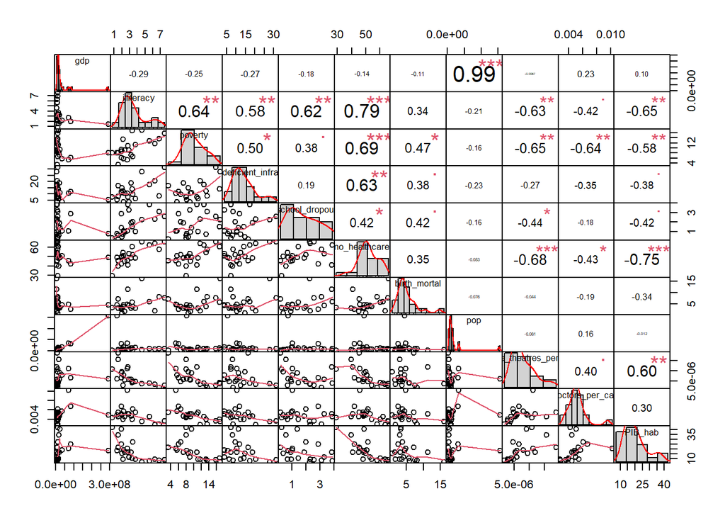

De cette base de données nous apportons quelques modifications. Nous retirons la ligne Buenos Aires qui n’est pas concernée par ces programmes car bénéficiant déjà de son propre programme. Ensuite avec les variables gdp et pop qui sont corrélées à 0,99, nous crééons la variable *PIB_hab* que nous conserverons plutôt que les deux autres car elle semble plus représentative du niveau de richesse d’une région, que les variables qui la compose. Nous retirons également toutes les variables dont la corrélation avec la variable poverty n’est pas significative avec au moins ** entre elles.  
Nous conservons également la variable movie_theatres_per_cap qui est très faible partout (0,0000..) mais significative.

A présent, notre base de données ne contient plus que les variables suivantes. Voici quelques statistiques descriptives les concernant.

**Tableau : Statistiques descripitives (n=21)**

| variable | n | min | max | mean | median | sd |
| --- | --- | --- | --- | --- | --- | --- |
| doctors_per_cap | 21 | 0.003 | 0.010 | 0.005 | 0.005 | 0.002 |
| illiteracy | 21 | 0.791 | 7.518 | 3.313 | 2.773 | 1.850 |
| movie_theatres_per_cap | 21 | 0.000 | 0.000 | 0.000 | 0.000 | 0.000 |
| no_healthcare | 21 | 29.232 | 65.813 | 50.863 | 49.946 | 9.397 |
| PIB_hab | 21 | 7.181 | 42.574 | 18.327 | 16.722 | 10.630 |
| poverty | 21 | 3.399 | 17.036 | 10.009 | 9.234 | 3.852 |

Ainsi, les variables poverty (taux de la pop sous le seuil de pauvreté), illiteracy (taux de la population n’ayant pas reçu d’éducation formelle) et no_healthcare ( taux de la population active n’ayant pas accès à des soins de soins de santé sont des variables représentatives de la pauvreté/ précarité donc plus les valeurs associées sont fortes et plus les régions peuvent être qualifiées de vulnérable. Au contraire, lorsqu’ils sont faibles c’est un bon signe pour les régions qui potentiellement appartiendront aux régions riches. Pour les variables PIB_hab et doctors_per_cap (nombre de docteurs par habitant), c’est l’inverse c’est à dire que lorsque leurs valeurs sont élevées il s’agit plutôt de régions riches car les deux variables correspondent à des indicateurs de richesse. Avec ces 5 variables, on aborde finalement plusieurs dimensions de la pauvreté, notamment la pauvreté monétaire (PIB_hab et poverty qui porte sur le revenu), mais aussi la dimension de la santé ( avec la variable no_healthcare) et l’accès à des besoins fondamentaux tel que l’éducation (illiteracy). Des dimensions que l’on retrouve dans la plupart des indicateurs de niveau de vie comme l’IDH par exemple.

Finalement, la région ayant le plus faible taux de sa population sous le seuil de pauvreté a 3,4% de sa population ayant un revenu sous le seuil de pauvreté. A contrario, la région ayant le plus fort taux pour la variable “poverty” possède 17% de sa population sous ce seuil. Ou alors, le nombre de patients pour un docteur dans l’une de ces régions est de 1/0,003 soit 333 patients pour un docteur dans la région ou le rapport présence de médecin rapporté à la population est le plus faible. 1/0,01 soit 100 patients pour un médecin en moyenne dans la ville ou le rapport est le plus élevé, et une moyenne toutes régions confondues de 200 patients par médecin (1/0,005).

### IV. Résultats empiriques

#### 1 - ACP

##### ACP - Problématiques et conditions de l’ACP

A présent, même si nous avons réduit notre tableau de données, il va falloir proposer un résumé des données restantes pour pouvoir dresser des profils de régions et notamment déterminer quelles sont celles qui correspondraient aux programmes énoncés précedemment. L’ACP dont l’objectif est justement de résumer l’information principale d’un jeu de données conntenant des lignes individus et colonnes variables semble être adapté. On va ainsi chercher à déterminer des profils de régions similaires. Mais avant cela il va falloir vérifier que l’ACP peut être appliquée: On va s’assurer de la qualité de l’ensemble des corrélations avec un test de Bartlett.

Soit deux hypothèses H0 et H1, Soit H0: les variances de k échantillons tirés sont identiques et H1, au moins deux d’entre elles sont différentes.

Lorsqu’on applique ce test on obtient bien une p-valeur < 0,05 (p-valeur = 8.6126692^{-9}), ce qui nous permet de rejeter H0 et d’accepter H1. Nous pouvons donc appliquer l’ACP.

##### ACP - Nombres d’axes et inertie

**Graphique : Inertie**

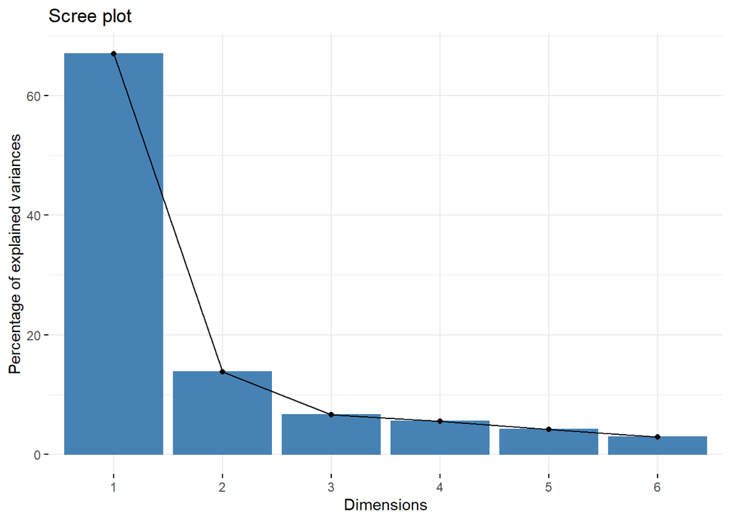

Le barplot ci-dessus nous renseigne sur l’inertie des axes factoriels. Une méthode courante pour déterminer le nombre d’axe serait de rechercher une cassure apparente, qui indiquerait le nombre d’axe à conserver. Celle ci apparait dès le deuxième axe.

De plus, les 2 premiers axes de l’ analyse expriment à eux seuls 80,8% de l’inertie totale ; cela signifie que 80,8% de la variabilité totale du nuage des individus (ou des variables) est représentée dans ce plan. La première dimension reflète à elle seule 67% de cette inertie et la seconde 13,8%. La somme des deux donne un pourcentage élevé, et le plan qu’elles forment représente donc bien la variabilité de l’ensemble.

Dans la dimension 1 les variables no_healthcare et illiteracy contribuent le plus, mais la plupart des variables contribuent de manière importante. En revanche Dans la dimension 2 les variables qui contribuent le plus sont doctors_per_cap qui contribue excessivement, ce qui est par ailleurs un signe potentiel d’instabilité, et la variable PIB_hab (cf - annexe 1 & 2).

Il en est de même pour ce qui est de la qualité de la représentation qu’on peut observer avec le cos2 (cf- annexe 3 & 4).

Nous pouvons à présent visualiser nos variables sur le graphe des variables :

**ACP - Graphe des variables**

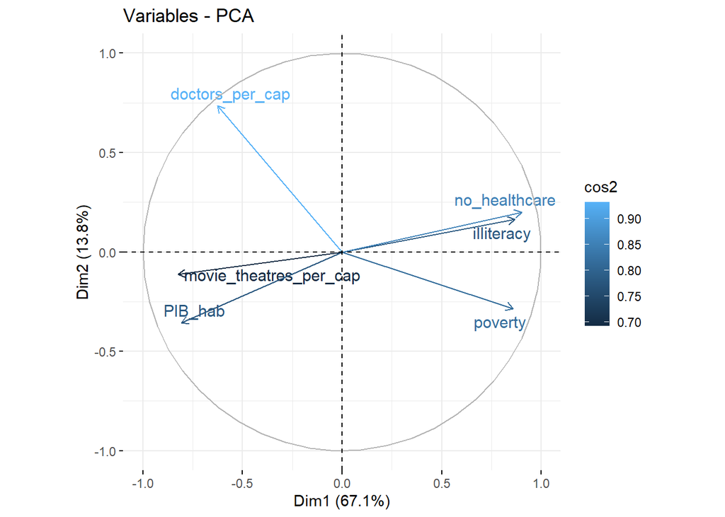

Dans l’ensemble on observe une corrélation négative entre d’un côté les variables (qui sont entre elles corrélées positivement ) poverty - illiteracy- no_healthcare et les variables (entre elles corrélées positivement également) PIB_hab, doctors_per_cap et movie_theatres_per_cap de l’autre côté, ce qui est plutôt cohérent car cela se traduit par le fait qu’une région qui aurait des indicateurs de pauvreté élevé aurait tendance à avoir des indicateurs de richesse faible…

Cela peut être plus parlant en appuyant ces observations avec le graphique concernant les individus cette fois.

**ACP - Graphe des individus**

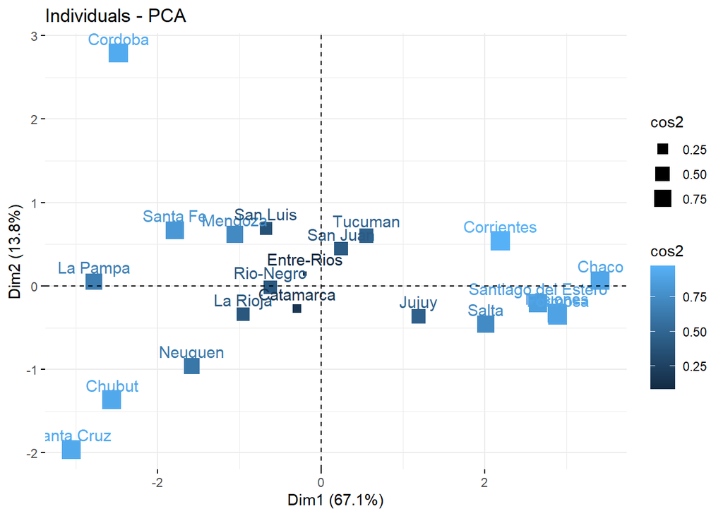

Ainsi, les régions telles que Formosa, Chaco, Corrientes, Santiago del Estero, Misiones, et Salta que l’on retrouve notamment à droite sur le graphe, sont caractérisés par une coordonnée fortement positive sur l’axe.

Ces régions possèdent ainsi des taux élevés de :

- habitants étant sous le seuil de pauvreté (représentés par la variable poverty),
- de population n’ayant pas accès aux soins (no_healthcare)
- et d’illetrisme (illiteracy).

Ainsi que des taux faibles concernant :

- le pib/hab (PIB_hab),
- le nombre de salles de cinéma par personne (movie_theatres_per_cap) - ainsi que le nombre de docteurs par habitant (même s’il aurait été plus logique de le prendre dans le sens inverse, c’est à dire le nombre d’habitants pour un docteur) avec la variable doctors_per_cap.

Ainsi, c’est parmi ces régions, que l’on peut considérer comme pauvres et vulnérables parmi les régions d’Argentine, que l’on selectionnera nos deux régions devant bénéficier du programme pour les régions les plus pauvres.  
Ces régions s’opposent à des régions dont les coordonnées sur l’axe principal sont négatives car on les retrouve à gauche. C’est notamment le cas pour Santa Cruz, Chubut, Cordoba et La Pampa.

Ces régions possèdent contrairement aux premières des taux faibles de :

- pauvreté (représentés par la variable poverty),
- de population n’ayant pas accès aux soins (no_healthcare)
- et d’illetrisme (illiteracy).

Ainsi que des taux élevés concernant :

- le pib/hab (PIB_hab),
- le nombre de salles de cinéma par personne (movie_theatres_per_cap) - ainsi que le nombre de docteurs par habitant (même s’il aurait été plus logique de le prendre dans le sens inverse c’est à dire le nombre d’habitants pour un docteur) avec la variable doctors_per_cap.

Ainsi, c’est très probablement parmi ces régions que l’on devra séléctionner les deux régions les plus riches, afin qu’elles bénéficient du programme les visant.

#### 2 - Méthode des K-means

A présent, il peut être pertinent de passer à une analyse non supervisée, avec l’aide notemment de la méthode des K-means qui est un bon complément à notre ACP de départ. Pour rappel, la méthode des K-means permet de séparer en K classes homogènes les régions suivant les ressemblances entre leurs profils à partir de k individus choisis au hasard qui constitueront le centre des classes. Puis on affecte les différents individus aux centres dont ils sont le plus proche et une fois qu’ils sont affectés le centre est recalculé et les individus réafféctés, jusqu’à ce que les centres et individus ne bougent plus. La méthode à suivre est la suivante, dans un premier temps, à partir des données de départ, qu’on va standardiser, il va falloir construire la partition et caractériser les différentes classes.

**Calcul et Visualisation de la matrice des distances**

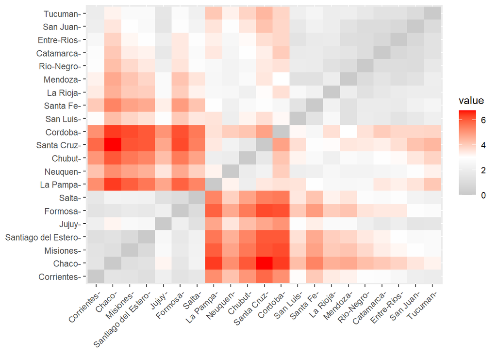

Ainsi, plus les régions présentent de grandes différences et plus leur intersection est rouge, notamment par rapport à celles qui semblent assez similaires et qui ont leur intersection grise. Ainsi, et cela est cohérent avec les résultats obtenus lors de notre ACP les régions telles que Chaco et Corrientes ont des profils similaires, tandis qu’elles ont une grande distance traduisant un profil différent avec la région de La Pampa par exemple.

Pour déterminer le nombre optimal de cluster plusieurs méthodes sont possibles :

**Déterminer le nombre optimal de clusters : “Elbow”**

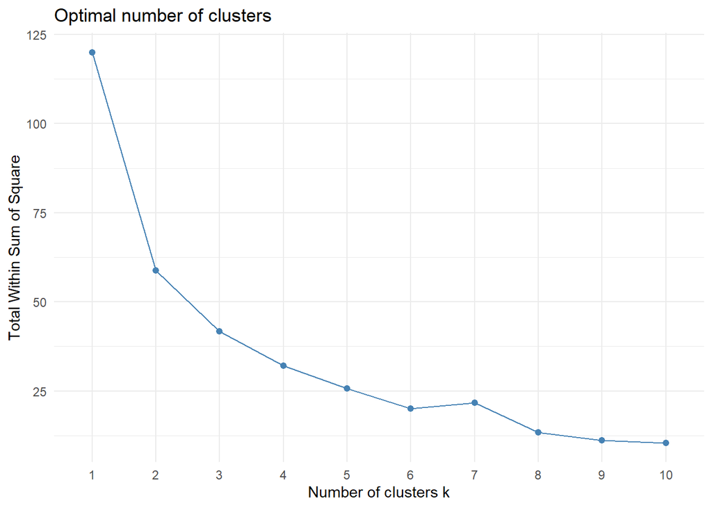

**Déterminer le nombre optimal de clusters : “Silouhette”**

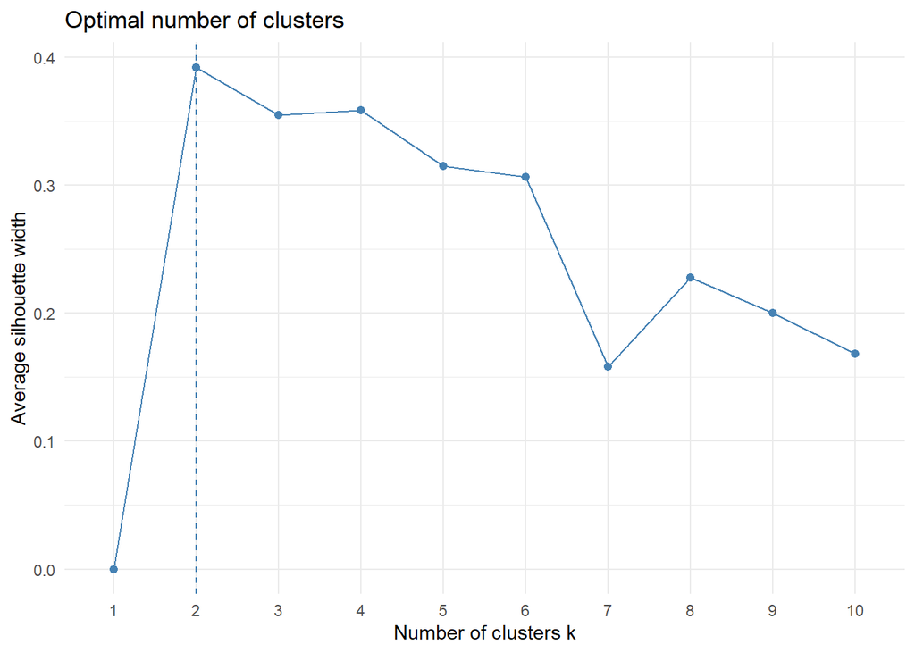

Ici, la méthode nous recommande comme nombre de clusters optimal k=2.

Pour trancher nous allons voir ce que nous recommande la dernière méthode :

**Déterminer le nombre optimal de clusters : “Gap_Stat.”**

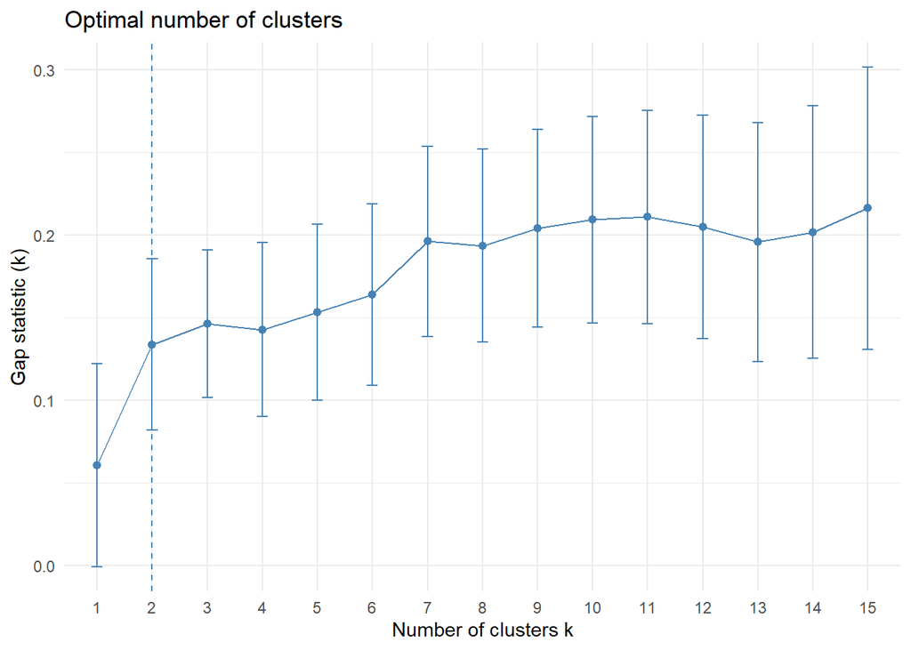

Ici, le graphique parle de lui même, on conserve donc k=2 car deux méthodes sur 3 nous le recommande.

**Cluster plot : k=2**

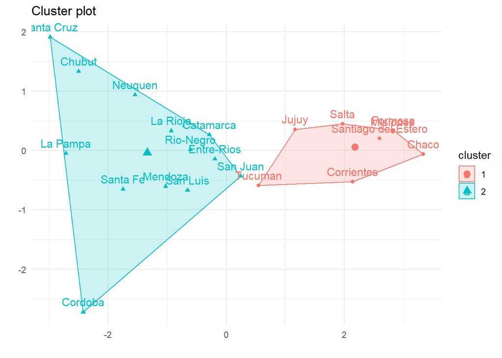

| Cluster | illiteracy | poverty | no_healthcare | movie_theatres_per_cap | doctors_per_cap | PIB_hab |
| --- | --- | --- | --- | --- | --- | --- |
| 1 | 5.0168 | 14.0484 | 59.7174 | 0 | 0.0038 | 9.1432 |
| 2 | 2.2649 | 7.5238 | 45.4139 | 0 | 0.0055 | 23.9790 |

#### 3 - Clustering et algorithme non supervisés (HC)

A présent, passons à une classification ascendante hiérachique, dont le but est de regrouper les individus par groupe les plus homogènes possibles, c’est-à-dire minimiser la variance intra groupe tout en maximisant la variance inter groupe.

Nous choisissons la distance euclidienne, car l’échantillon étant agrégé à un niveau macro, nous le permet.

On peut alors observer la matrice des distances :

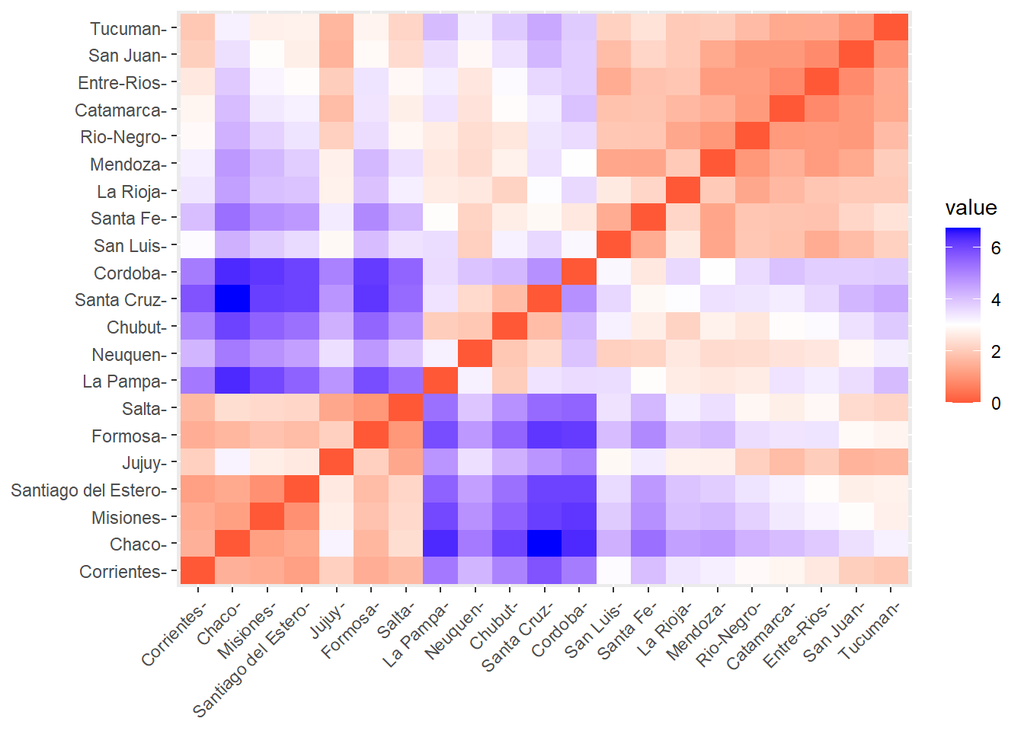

```
##   average    single  complete      ward
## 0.6332134 0.4998909 0.7698358 0.8583835
```

Au regard des résultats obtenu sur les ”ac”, on peut retenir la methode de Ward comme étant la meilleure.

Pour déterminer le nombre optimal de cluster: La encore, l’utilisation des différentes méthodes me fait conserver k=2 (cf- annexe a,b & c)

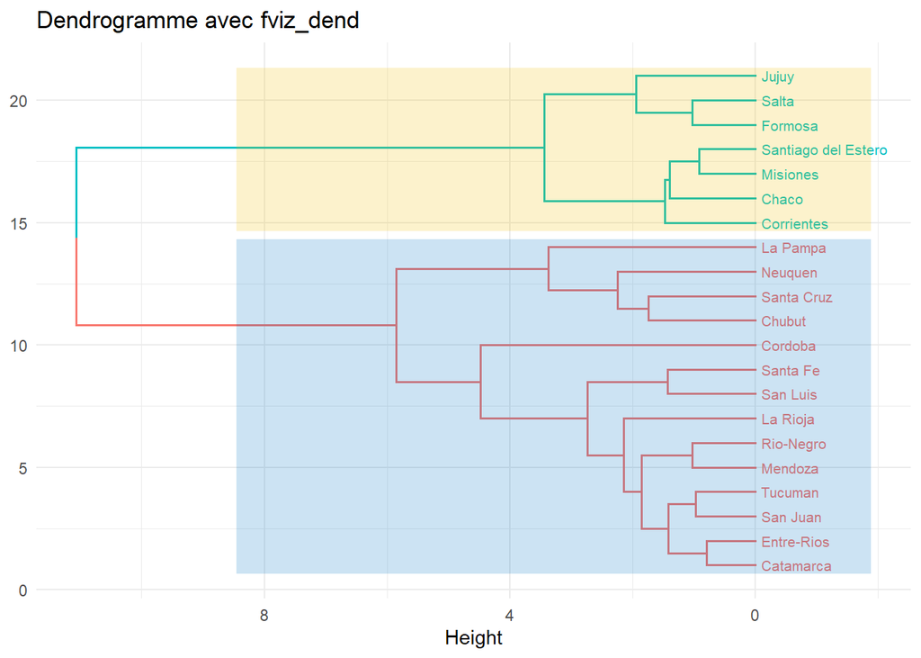

A présent, nous pouvons visualiser sur un plan à deux dimensions comme on l’a fait pour la méthode de l’ACP précédemment. On retrouve bien les deux groupes, avec un seul changement de groupe : Tucuman dont la position assez centrique entre les deux groupes n’a pas permis de conserver le même groupe que celui précedemmant attribué lors de la méthode des Kmeans .

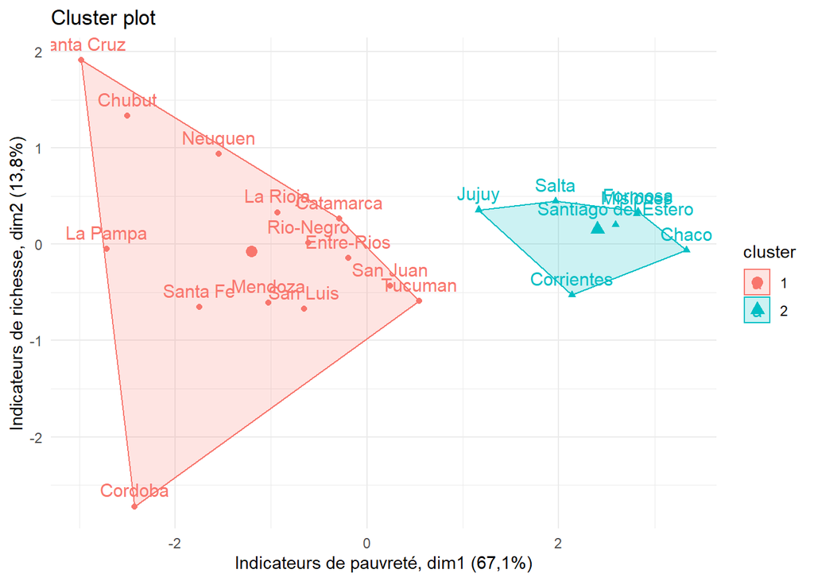

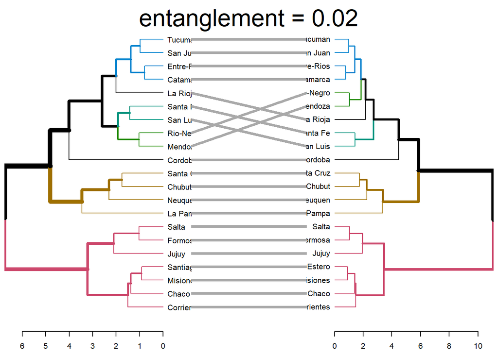

De plus, la qualité de l’alignement des deux arbres peut être mesurée à l’aide de la fonction entanglement() qui donne l’enchevêtrement entre les deux dendrogrammes). Plus celui ci est proche de 0 et plus cela signifie qu’il y a un bon alignement entre les variables. Ici il est de 0,02, ce qui est bon signe.

### V. Résultats et discussion

Je vais alors trier mes régions du cluster 1 et du cluster 2 en fonction d’un critère (une variable), pour le cluster 1 je vais conserver la variable poverty ( critère important de la dimension 1), et pour le cluster 2 je conserve la variable PIB_hab (critère important de la dimension 2.

|  | illiteracy | poverty | no_healthcare | movie_theatres_per_cap | doctors_per_cap | PIB_hab | cluster |
| --- | --- | --- | --- | --- | --- | --- | --- |
| Tucuman | 3.770370 | 11.214239 | 48.2242 | 4.80e-06 | 0.0055007 | 9.567956 | 1 |
| La Rioja | 2.773210 | 10.875152 | 40.8341 | 1.20e-05 | 0.0050923 | 16.756031 | 1 |
| Neuquen | 1.943750 | 9.456635 | 48.7431 | 9.10e-06 | 0.0050665 | 40.931431 | 1 |
| Catamarca | 2.344140 | 9.234095 | 45.0456 | 5.40e-06 | 0.0045021 | 16.722352 | 1 |
| San Juan | 2.963260 | 9.050784 | 52.9684 | 5.90e-06 | 0.0050436 | 12.131632 | 1 |
| Rio-Negro | 2.031420 | 8.678391 | 49.9463 | 9.40e-06 | 0.0048979 | 16.072442 | 1 |
| Chubut | 1.548060 | 8.051752 | 39.5473 | 1.57e-05 | 0.0044981 | 34.860686 | 1 |
| Santa Cruz | 0.791485 | 8.024762 | 29.2321 | 1.10e-05 | 0.0042706 | 42.573981 | 1 |
| Entre-Rios | 3.185580 | 7.288751 | 48.6571 | 5.70e-06 | 0.0046788 | 16.782775 | 1 |
| San Luis | 3.433650 | 6.593771 | 51.6154 | 4.60e-06 | 0.0061021 | 27.250930 | 1 |
| Santa Fe | 1.975940 | 6.081012 | 41.9660 | 6.60e-06 | 0.0066717 | 25.540067 | 1 |
| Mendoza | 2.200200 | 5.692798 | 50.5843 | 8.10e-06 | 0.0057202 | 19.225264 | 1 |
| Cordoba | 2.714140 | 5.382380 | 45.7640 | 1.12e-05 | 0.0101754 | 20.962931 | 1 |
| La Pampa | 1.539300 | 3.398774 | 45.4764 | 1.88e-05 | 0.0054146 | 21.916415 | 1 |

|  | illiteracy | poverty | no_healthcare | movie_theatres_per_cap | doctors_per_cap | PIB_hab | cluster |
| --- | --- | --- | --- | --- | --- | --- | --- |
| Salta | 3.34609 | 16.87050 | 60.4230 | 4.1e-06 | 0.0039911 | 11.065861 | 2 |
| Jujuy | 2.15139 | 13.36797 | 54.1615 | 3.0e-06 | 0.0039581 | 9.631473 | 2 |
| Santiago del Estero | 6.27209 | 11.75900 | 63.6637 | 3.4e-06 | 0.0028215 | 9.597027 | 2 |
| Chaco | 7.51758 | 15.86262 | 65.5104 | 2.8e-06 | 0.0036048 | 9.317753 | 2 |
| Misiones | 6.86395 | 13.52979 | 57.8339 | 1.8e-06 | 0.0028804 | 8.757160 | 2 |
| Corrientes | 5.60242 | 12.74719 | 62.1103 | 4.0e-06 | 0.0044953 | 8.027456 | 2 |
| Formosa | 4.61064 | 17.03558 | 65.8126 | 3.8e-06 | 0.0034405 | 7.180932 | 2 |

### Références

- Emmanuelle Benicourt, « La pauvreté selon le PNUD et la Banque mondiale », Études rurales [En ligne], 159-160 | 2001, mis en ligne le 03 janvier 2017, consulté le 10 mars 2022. URL : http://journals.openedition.org/etudesrurales/68 ; DOI : https://doi.org/10.4000/etudesrurales.68
- Banque mondiale (BM) — 2000, World development report : attacking poverty [traduction française : Rapport sur le développement dans le monde : combattre la pauvreté].
- Programme des Nations unies pour le développement (PNUD) 2000, Vaincre la pauvreté humaine.

### Annexes

##### Graphiques supplémentaires

*annexe 1 :*

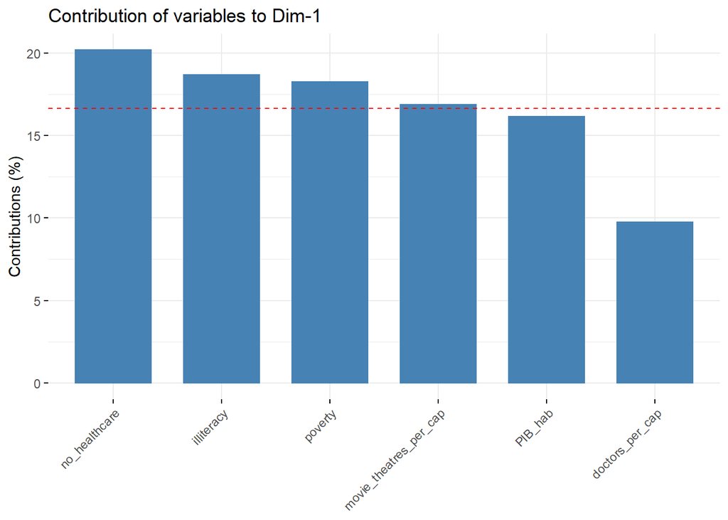

*annexe 2 :*

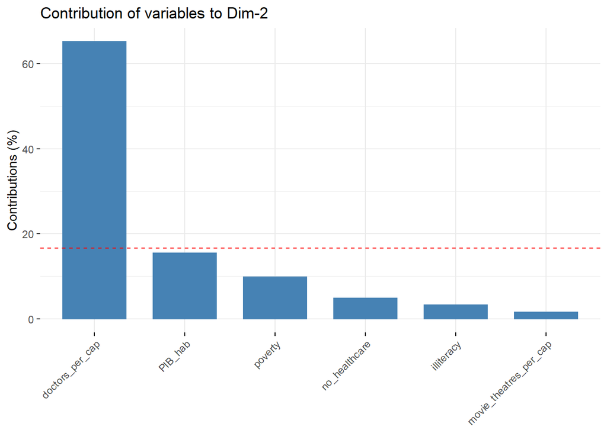

*annexe 3 :*

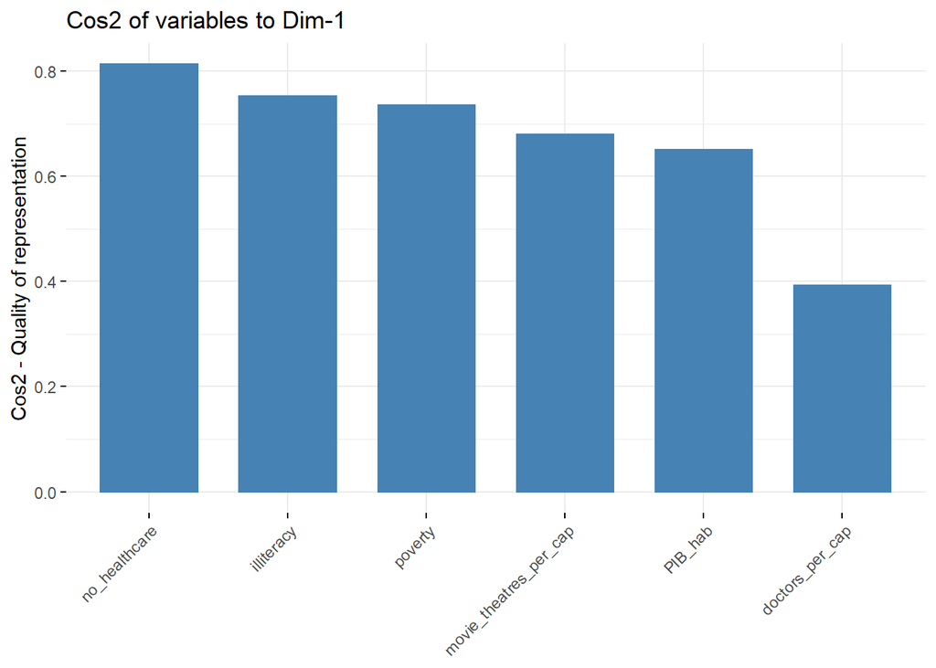

*annexe 4 :*

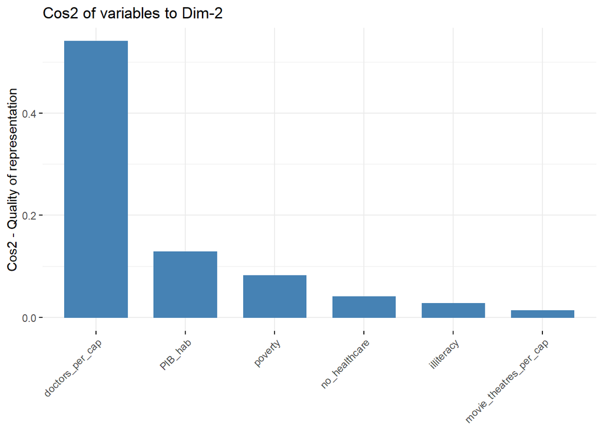

*annexe a :*

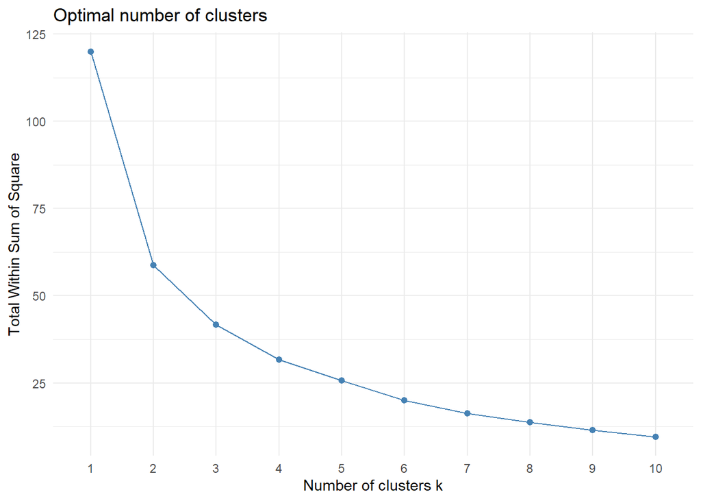

*annexe b :*

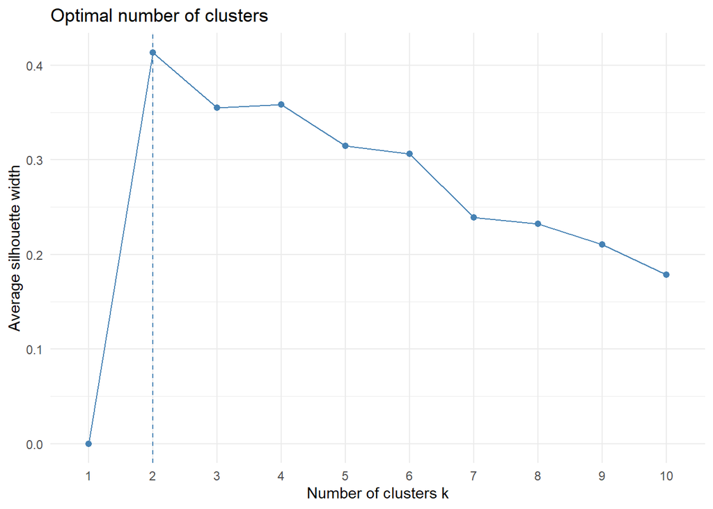

*annexe c :*

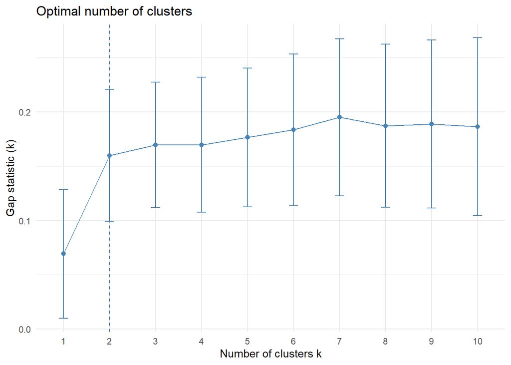

##### Intégralité du code :

```r
BaseArgentina<-read.csv(file="données_argentina.csv", header=TRUE, row.names=1)
PIB_hab<-data.frame(matrix(BaseArgentina$gdp/BaseArgentina$pop))
names(PIB_hab)<-c("PIB_hab")
argentina<-cbind(BaseArgentina, PIB_hab)
chart.Correlation(argentina, histogram=TRUE, pch=17)


#Packages
library(PerformanceAnalytics)
library(kableExtra)
library(rstatix)
library(rstatix)
library(FactoMineR)
library(factoextra)
library(psych)
library(ggplot2)
library(corrplot)
library(ggpubr)


BaseArgentina<-read.csv(file="données_argentina.csv", header=TRUE, row.names=1)
PIB_hab<-data.frame(matrix(BaseArgentina$gdp/BaseArgentina$pop))
names(PIB_hab)<-c("PIB_hab")
argentina<-cbind(BaseArgentina, PIB_hab)
chart.Correlation(argentina, histogram=TRUE, pch=17)

argentina<-argentina[-1,]
argentina<-argentina[,-1]
argentina<-argentina[,-3]
argentina<-argentina[,-3]
argentina<-argentina[,-5]
argentina<-argentina[,-4]


stat <-get_summary_stats(argentina, show = c("min", "max","mean","median", "sd"))
kable(stat, digits = 3) %>% kable_classic_2() %>% kable_styling(font_size = 15,)

library(corrplot)
mat_r <- cor(argentina)
corrplot(mat_r, method = "number", type ="lower")

bar.test <- cortest.bartlett(mat_r,n=nrow(argentina))
Pval<-bar.test$p.value

Z <- argentina
for(j in 1:5) Z[,j ] =
  (argentina[,j] - mean (argentina[,j]))/sd(argentina[,j])
(R<- cor(Z))
eigen(R)
L <- eigen(R)$values
blue <- rgb(0, 0, 1, alpha=0.6)
mycol <- rgb(0, 0, 255, max
             = 255, alpha = 15, names =
               "blue50")

barplot(cumsum(L)/sum(L),
        col=mycol)
barplot(L/sum(L), add=T,
        col=blue)
L/ sum(L)*100

res.pca <- PCA(argentina, graph = FALSE)
eig.val <- get_eigenvalue(res.pca)
fviz_eig(res.pca)

M <- (as.matrix(Z)) %*%
  t(as.matrix(Z))
eigen(M)
red <- rgb(1, 0, 0, alpha=0.6)
mycol2 <- rgb(255, 0, 0, max =
                255,
              alpha = 15, names = "red50")
L <- eigen(M)$values
barplot(cumsum(L)/ sum(L), col =
          mycol2)
barplot(L/sum(L),add=T, col=red)
L/ sum(L)*100

library(tidyverse)
t(as.matrix(Z)) %*%
  eigen(M)$vectors
phi <- eigen(M)$vectors[,1:2]
row.names(phi) = rownames(Z)
colnames(phi) = c(" PC1 ","PC2")
PC1 = t(as.matrix(Z)) %*% phi[
  ,1]
PC2 = t(as.matrix(Z)) %*% phi[
  ,2]

plot (PC1 , PC2, pch = 19,
      ylim=c(-5, 5),
      xlim=c(-7, 4), col=red,
      panel.first=grid())
text (PC1 ,PC2 , colnames(Z),
      pos =3, col = red, cex=0.8)
arrows(0,0, PC1 , PC2, col =
         red, lwd=1.5)

detach("package:tidyverse")
annexe1<-fviz_contrib(res.pca, choice = "var",
             axes = 1)
annexe2<-fviz_contrib(res.pca, choice = "var",
             axes = 2)

annexe3<-fviz_cos2(res.pca , choice ="var",
          axes = 1)
annexe4<-fviz_cos2(res.pca , choice ="var",
          axes = 2)
# avec une couleur fonction des cos2
fviz_pca_var(res.pca, col.var =
               "cos2", repel = TRUE )
# ou de la contribution des variables
fviz_pca_var(res.pca, col.var ="contrib")

#fviz_pca_ind(res.pca, col.ind = "cos2", repel = TRUE)
fviz_pca_ind(res.pca,
             col.ind = "cos2", pointsize =
               "cos2",
             pointshape = 15)

fviz_contrib(res.pca, choice = "ind", axes = 1:3)
fviz_contrib(res.pca, choice = "ind", axes = 1)
fviz_contrib(res.pca, choice = "ind", axes = 2)
fviz_contrib(res.pca, choice = "ind", axes = 1:2)
fviz_pca_biplot(res.pca, repel = TRUE )

km1 <- kmeans(argentina2, centers =
                2, nstart = 25)

# Visualisation des groupes identifiés
#fviz_cluster(km1, data = argentina2,  xlab="", ylab="")+ theme_minimal()

# En variant le nombre de clusters
km2 <- kmeans(argentina2, centers = 3,
              nstart = 25)
km3 <- kmeans(argentina2, centers = 4,
              nstart = 25)
km4 <- kmeans(argentina2, centers = 5,
              nstart = 25)
km5 <- kmeans(argentina2, centers = 6,
              nstart = 25)

# Comparaisons visuelles
p1 <- fviz_cluster(km1, geom =
                     "point", data = argentina2) + ggtitle("k= 2")
p2 <- fviz_cluster(km2, geom =
                     "point", data = argentina2) + ggtitle("k
= 3")
p3 <- fviz_cluster(km3, geom =
                     "point", data = argentina2) + ggtitle("k
= 4")
p4 <- fviz_cluster(km4, geom =
                     "point", data = argentina2) + ggtitle("k
= 5")

p5 <- fviz_cluster(km5, geom =
                     "point", data = argentina2) + ggtitle("k
= 5")

library(gridExtra)
annexe5 <-grid.arrange(p1, p2, p3, p4, nrow =2)


# 1/ Déterminer le nombre optimal de clusters : "Elbow"
fviz_nbclust(argentina2, kmeans,
             method = "wss")+theme_minimal()

# 2/ Déterminer le nombre optimal de clusters : "Silouhette"
fviz_nbclust(argentina2, kmeans,
             method = "silhouette")+theme_minimal()

# 3/ Déterminer le nombre optimal de clusters : "Gap_Stat."
library(cluster)
gap_stat <- clusGap(argentina2, FUN =
                      kmeans,
                    nstart = 25,
                    K.max = 15, B = 50)
#print(gap_stat,method ="firstmax")
fviz_gap_stat(gap_stat)+
  theme_minimal()

final <- kmeans(argentina2, 2, nstart
                = 25)
#print(final)
fviz_cluster(final, data =
               argentina2,
             xlab = "", ylab = "")+
  theme_minimal()

MClust <- argentina %>%
  mutate(Cluster = final$cluster) %>%
  group_by(Cluster) %>%
  summarise_all("mean")
kable(MClust, digits = 4) %>%
  kable_minimal()
# Ajouter une variable k
k <- cbind(argentina,
                 cluster = final$cluster)

distanceE <- get_dist(argentina2)
# Ou encore avec la fonction "dist"
distanceE <- dist(argentina2, method =
                    "euclidean")
# Visualiser la matrice des dist. eucl.
fviz_dist(distanceE)

# Matrice des dissimilarités entre observations (distances euclidiennes)
#distanceE
# CAH avec un Complete Linkage
hc1 <- hclust(distanceE, method =
                "complete" )
# Plot pour le dendrogramme
#plot(hc1, cex = 0.6, hang = -1)

# fonction AGNES
hc2 <- agnes(distanceE, method =
               "complete")
# coefficient d’agglomération
# méthodes à comparer selon l’agglomerative coefficient
m <- c( "average", "single",
        "complete", "ward")
names(m) <- c( "average", "single",
               "complete", "ward")

# fonction pour calculer les différents coefficients
ac <- function(x)
agnes(distanceE, method = x)$ac

library(purrr)
map_dbl(m,ac)
#14 dans le groupe 1 et 7 dans le groupe 2.

hc3 <- agnes(distanceE, method = "ward")
pltree(hc3, cex = 0.6, hang = -1, main = "Dendrogramme (AGNES)")

hc5 <- hclust(distanceE, method ="ward.D2" )

fviz_dend(hc3 , k = 2, cex =
0.55 , horiz = TRUE , rect = TRUE ,
rect_border = "jco", rect_fill = TRUE ,
main = "Dendrogramme avec fviz_dend")+theme_minimal()

# Couper l’arbre en 2 groupes
hc5 <- hclust(distanceE, method =
                "ward.D2" )
sub_grp <- cutree(hc5, k = 2)

# Nombre d’observations dans chaque cluster
#table(sub_grp)
# Ajouter une variable "cluster" à la base de données initiale
library(tidyverse)

argentina %>%
  mutate(cluster = sub_grp) %>%
  head
plot(hc5, cex = 0.6)
rect.hclust(hc5, k = 2, border =
              2:5)
detach("package:tidyverse")

# Visualiser sur un plan à deux dimensions (ACP comme k-means) (RAPPEL modifier le nom des axes)
fviz_cluster(list(data = argentina2,
                  cluster = sub_grp), ylab =
               "Indicateurs de richesse, dim2 (13,8%)",
             xlab = "Indicateurs de pauvreté, dim1 (67,1%)")+
  theme_minimal()

# Deux HC avec deux méthodes
hcA <- hclust(distanceE, method =
                "complete")
hcB <- hclust(distanceE, method =
                "ward.D2")
# Cr´eer les deux dendrogrammes
dend1 <- as.dendrogram(hcA)
dend2 <- as.dendrogram(hcB)
# Comparaison
library(dendextend)

dend_list <- dendlist(dend1, dend2)
tanglegram(dend1, dend2, highlight_distinct_edges = FALSE, common_subtrees_color_lines = FALSE, common_subtrees_color_branches = TRUE, main = paste("entanglement =", round(entanglement(dend_list), 2)) )

# 1/ Déterminer le nombre optimal de clusters : "Elbow"
annexea<-fviz_nbclust(argentina2, FUN = hcut, method = "wss")+theme_minimal()

# 2/ Déterminer le nombre optimal de clusters :"Silouhette"
annexeb<-fviz_nbclust(argentina2, FUN = hcut,method = "silhouette")+theme_minimal()

# 3/ Déterminer le nombre optimal de clusters : "Gap Stat."
library(cluster)
gap_stat <- clusGap(argentina2, FUN =hcut, nstart = 25, K.max = 10, B = 50)
#print(gap_stat, method = "firstmax")
annexec<-fviz_gap_stat(gap_stat)+theme_minimal()

cluster<-data.frame(matrix(sub_grp))
names(cluster)<-c("cluster")
argentina<-cbind(argentina,cluster)

argentina_Cluster1<- argentina[argentina$cluster ==1,]
argentina_Cluster2<- argentina[argentina$cluster ==2,]

Cl1<-argentina_Cluster1[order((-argentina_Cluster1$poverty)),]
kable(Cl1)

Cl2<-argentina_Cluster2[order((-argentina_Cluster2$PIB_hab)),]
kable(Cl2)
```